# DEFENSIVE TRAITS A.barbata SIBECOL 2025

Andrés Delgado Galán

2025-05-09

### A.barbata - PRODUCCIÓN DE FLORES

**sqrt(flor) ~ trat + clip + trat:clip**  
n = **53**

R² = **0.2974161**

##### AVflor Post-hoc Comparisons with Tukeys HSD

| contrast | trat | estimate | SE | df | t.ratio | p.value |
| --- | --- | --- | --- | --- | --- | --- |
| no - yes | ex | -0.1473022 | 0.5103766 | 49 | -0.2886147 | 0.7740937 |
| no - yes | gra | 1.2050234 | 0.5405644 | 49 | 2.2291947 | 0.0304181 |

| contrast | clip | estimate | SE | df | t.ratio | p.value |
| --- | --- | --- | --- | --- | --- | --- |
| ex - gra | no | -2.360263 | 0.5312168 | 49 | -4.443125 | 5.06e-05 |
| ex - gra | yes | -1.007937 | 0.5200989 | 49 | -1.937972 | 5.84e-02 |

ANOVA Results for AVflor Model

| Response | Predictor | Sum Sq | Df | F value | Pr(>F) |
| --- | --- | --- | --- | --- | --- |
| AV flor | trat *** | 36.811 | 1 | 20.188 | 0.000 |
| AV flor | clip | 3.180 | 1 | 1.744 | 0.193 |
| AV flor | trat:clip · | 6.033 | 1 | 3.309 | 0.075 |
| AV flor | Residuals | 89.346 | 49 | NA | NA |

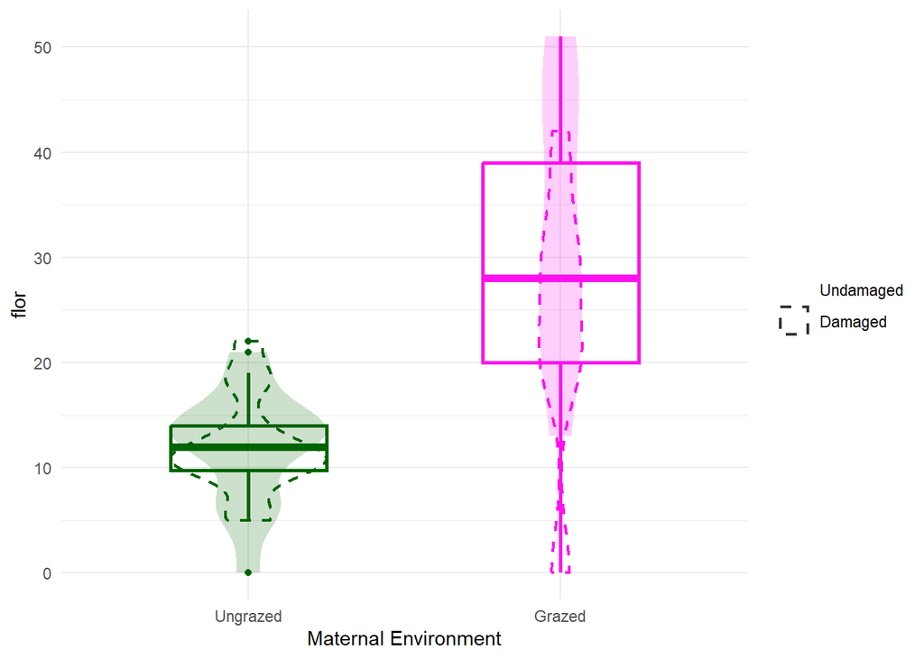

### A.barbata - PRODUCCIÓN DE FRUTOS

**sqrt(fruto) ~ trat + clip + trat:clip**  
n = **53**

R² = **0.3064264**

##### AVfruto Post-hoc Comparisons with Tukeys HSD

| contrast | trat | estimate | SE | df | t.ratio | p.value |
| --- | --- | --- | --- | --- | --- | --- |
| no - yes | ex | 0.0645351 | 0.4780565 | 49 | 0.1349948 | 0.8931690 |
| no - yes | gra | 0.8609303 | 0.5063327 | 49 | 1.7003255 | 0.0954094 |

| contrast | clip | estimate | SE | df | t.ratio | p.value |
| --- | --- | --- | --- | --- | --- | --- |
| ex - gra | no | -2.086857 | 0.4975770 | 49 | -4.194038 | 0.0001145 |
| ex - gra | yes | -1.290461 | 0.4871631 | 49 | -2.648931 | 0.0108365 |

ANOVA Results for AVfruto Model

| Response | Predictor | Sum Sq | Df | F value | Pr(>F) |
| --- | --- | --- | --- | --- | --- |
| AV fruto | trat *** | 37.273 | 1 | 23.299 | 0.000 |
| AV fruto | clip | 2.562 | 1 | 1.601 | 0.212 |
| AV fruto | trat:clip | 2.092 | 1 | 1.308 | 0.258 |
| AV fruto | Residuals | 78.389 | 49 | NA | NA |

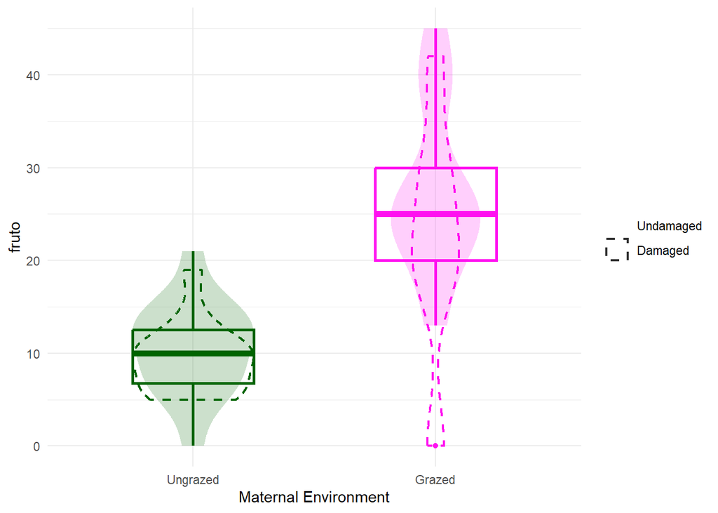

### A.barbata - PRODUCCIÓN DE HOJAS

**sqrt(hojas) ~ trat + clip + trat:clip**  
n = **53**

R² = **0.4268191**

##### AVhojas Post-hoc Comparisons with Tukeys HSD

| contrast | trat | estimate | SE | df | t.ratio | p.value |
| --- | --- | --- | --- | --- | --- | --- |
| no - yes | ex | -0.6991982 | 0.4078563 | 49 | -1.7143247 | 0.0927887 |
| no - yes | gra | 0.0098570 | 0.4319803 | 49 | 0.0228182 | 0.9818879 |

| contrast | clip | estimate | SE | df | t.ratio | p.value |
| --- | --- | --- | --- | --- | --- | --- |
| ex - gra | no | -2.203833 | 0.4245103 | 49 | -5.191470 | 0.0000040 |
| ex - gra | yes | -1.494777 | 0.4156257 | 49 | -3.596451 | 0.0007487 |

ANOVA Results for AVhojas Model

| Response | Predictor | Sum Sq | Df | F value | Pr(>F) |
| --- | --- | --- | --- | --- | --- |
| AV hojas | trat *** | 44.785 | 1 | 38.461 | 0.000 |
| AV hojas | clip | 1.764 | 1 | 1.515 | 0.224 |
| AV hojas | trat:clip | 1.659 | 1 | 1.424 | 0.238 |
| AV hojas | Residuals | 57.057 | 49 | NA | NA |

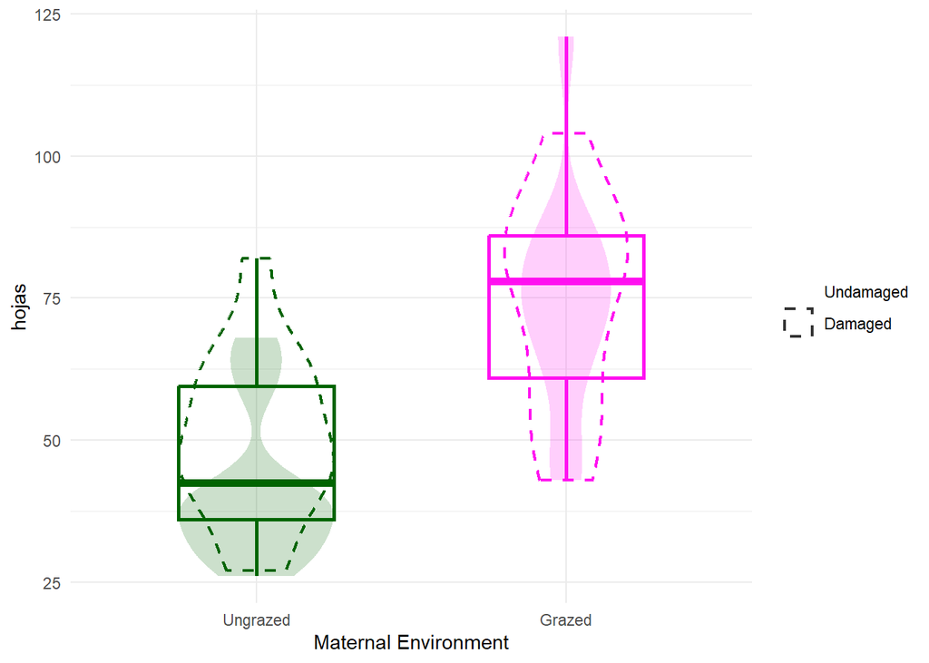

### A.barbata - ALTURA MÁXIMA

**sqrt(altura) ~ trat + clip + trat:clip**  
n = **51**

R² = **0.1102157**

##### AValtura Post-hoc Comparisons with Tukeys HSD

| contrast | trat | estimate | SE | df | t.ratio | p.value |
| --- | --- | --- | --- | --- | --- | --- |
| no - yes | ex | 0.5112305 | 0.4036647 | 47 | 1.266473 | 0.2115846 |
| no - yes | gra | 0.2790845 | 0.4278573 | 47 | 0.652284 | 0.5173956 |

| contrast | clip | estimate | SE | df | t.ratio | p.value |
| --- | --- | --- | --- | --- | --- | --- |
| ex - gra | no | -0.661413 | 0.4195486 | 47 | -1.576487 | 0.1216215 |
| ex - gra | yes | -0.893559 | 0.4122936 | 47 | -2.167288 | 0.0353129 |

ANOVA Results for AValtura Model

| Response | Predictor | Sum Sq | Df | F value | Pr(>F) |
| --- | --- | --- | --- | --- | --- |
| AV altura | trat * | 7.718 | 1 | 7.027 | 0.011 |
| AV altura | clip | 2.058 | 1 | 1.874 | 0.178 |
| AV altura | trat:clip | 0.171 | 1 | 0.156 | 0.695 |
| AV altura | Residuals | 51.623 | 47 | NA | NA |

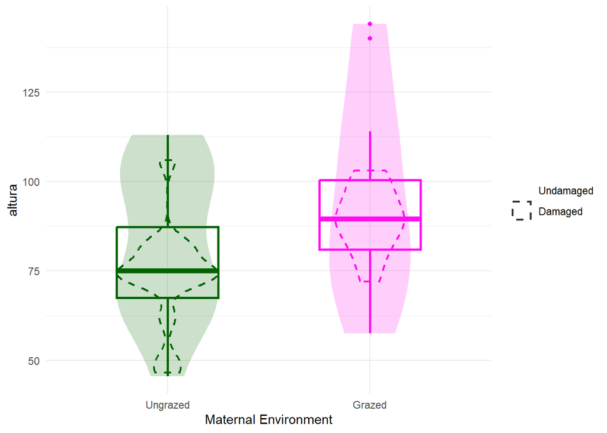

### A.barbata - SEMILLAS/FRUTO

**sqrt(seedfruto) ~ trat + clip + trat:clip**  
n = **53**

R² = **0.4674251**

##### AVseedfruto Post-hoc Comparisons with Tukeys HSD

| contrast | trat | estimate | SE | df | t.ratio | p.value |
| --- | --- | --- | --- | --- | --- | --- |
| no - yes | ex | 0 | 0 | 49 | 0.0 | 1.0000000 |
| no - yes | gra | 0 | 0 | 49 | 1.4 | 0.1678133 |

| contrast | clip | estimate | SE | df | t.ratio | p.value |
| --- | --- | --- | --- | --- | --- | --- |
| ex - gra | no | 0 | 0 | 49 | 0.000000 | 1.0000000 |
| ex - gra | yes | 0 | 0 | 49 | 1.455089 | 0.1520215 |

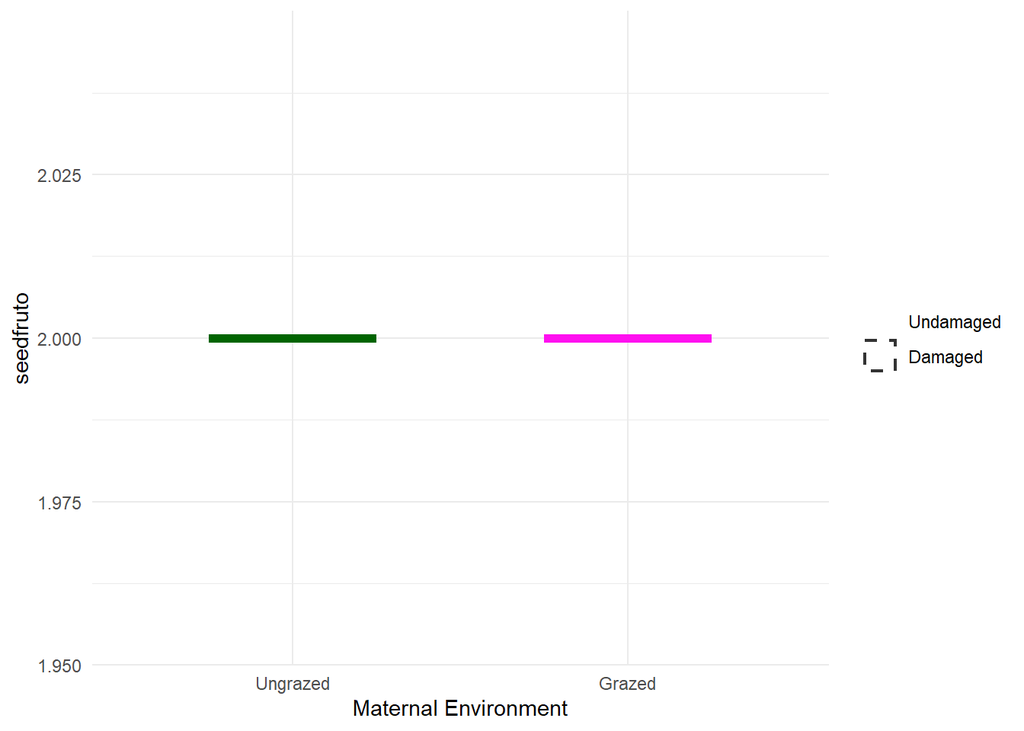

### A.barbata - PRODUCCIÓN DE SEMILLAS

**sqrt(seedtotal) ~ trat + clip + trat:clip**  
n = **53**

R² = **0.3064264**

##### AVseedtotal Post-hoc Comparisons with Tukeys HSD

| contrast | trat | estimate | SE | df | t.ratio | p.value |
| --- | --- | --- | --- | --- | --- | --- |
| no - yes | ex | 0.0912665 | 0.6760740 | 49 | 0.1349948 | 0.8931690 |
| no - yes | gra | 1.2175394 | 0.7160625 | 49 | 1.7003255 | 0.0954094 |

| contrast | clip | estimate | SE | df | t.ratio | p.value |
| --- | --- | --- | --- | --- | --- | --- |
| ex - gra | no | -2.951261 | 0.7036801 | 49 | -4.194038 | 0.0001145 |
| ex - gra | yes | -1.824988 | 0.6889527 | 49 | -2.648931 | 0.0108365 |

ANOVA Results for AVseedtotal Model

| Response | Predictor | Sum Sq | Df | F value | Pr(>F) |
| --- | --- | --- | --- | --- | --- |
| AV seedtotal | trat *** | 74.545 | 1 | 23.299 | 0.000 |
| AV seedtotal | clip | 5.124 | 1 | 1.601 | 0.212 |
| AV seedtotal | trat:clip | 4.185 | 1 | 1.308 | 0.258 |
| AV seedtotal | Residuals | 156.777 | 49 | NA | NA |

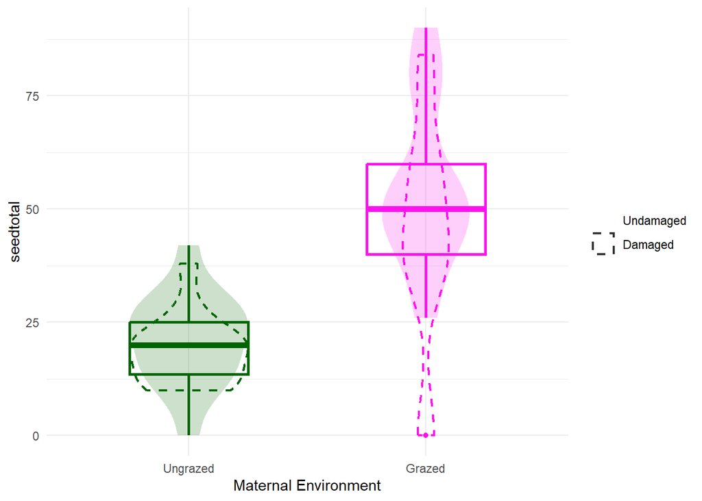

### A.barbata - PESO MEDIO DE LAS SEMILLAS

**sqrt(massseed) ~ trat + clip + trat:clip**  
n = **49**

R² = **0.815135**

##### AVmassseed Post-hoc Comparisons with Tukeys HSD

| contrast | trat | estimate | SE | df | t.ratio | p.value |
| --- | --- | --- | --- | --- | --- | --- |
| no - yes | ex | 0.0056536 | 0.0077177 | 45 | 0.7325524 | 0.4676301 |
| no - yes | gra | 0.0015894 | 0.0081890 | 45 | 0.1940911 | 0.8469781 |

| contrast | clip | estimate | SE | df | t.ratio | p.value |
| --- | --- | --- | --- | --- | --- | --- |
| ex - gra | no | 0.0843800 | 0.0081890 | 45 | 10.30400 | 0 |
| ex - gra | yes | 0.0803158 | 0.0077177 | 45 | 10.40668 | 0 |

ANOVA Results for AVmassseed Model

| Response | Predictor | Sum Sq | Df | F value | Pr(>F) |
| --- | --- | --- | --- | --- | --- |
| AV massseed | trat *** | 0.082 | 1 | 214.341 | 0.000 |
| AV massseed | clip | 0.000 | 1 | 0.444 | 0.509 |
| AV massseed | trat:clip | 0.000 | 1 | 0.130 | 0.720 |
| AV massseed | Residuals | 0.017 | 45 | NA | NA |

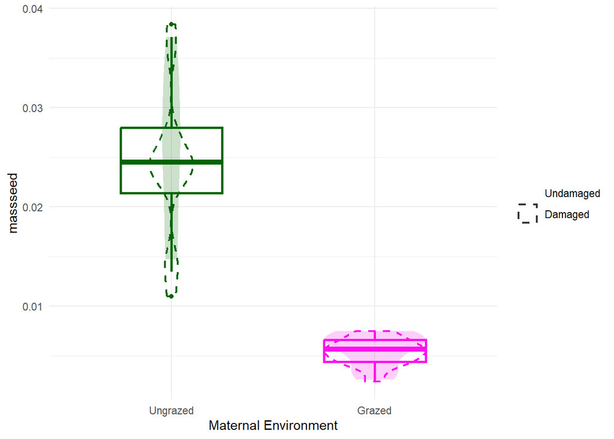

### A.barbata - SLA

**sqrt(SLA) ~ trat + clip + trat:clip**  
n = **44**

R² = **0.598101**

##### AVSLA Post-hoc Comparisons with Tukeys HSD

| contrast | trat | estimate | SE | df | t.ratio | p.value |
| --- | --- | --- | --- | --- | --- | --- |
| no - yes | ex | 0.9650707 | 0.8066578 | 40 | 1.196382 | 0.2385910 |
| no - yes | gra | -2.5531209 | 0.8836493 | 40 | -2.889292 | 0.0062072 |

| contrast | clip | estimate | SE | df | t.ratio | p.value |
| --- | --- | --- | --- | --- | --- | --- |
| ex - gra | no | -2.765887 | 0.8460298 | 40 | -3.269255 | 0.0022212 |
| ex - gra | yes | -6.284079 | 0.8460298 | 40 | -7.427728 | 0.0000000 |

ANOVA Results for AVSLA Model

| Response | Predictor | Sum Sq | Df | F value | Pr(>F) |
| --- | --- | --- | --- | --- | --- |
| AV SLA | trat *** | 223.369 | 1 | 57.213 | 0.000 |
| AV SLA | clip | 4.423 | 1 | 1.133 | 0.294 |
| AV SLA | trat:clip ** | 33.757 | 1 | 8.646 | 0.005 |
| AV SLA | Residuals | 156.167 | 40 | NA | NA |

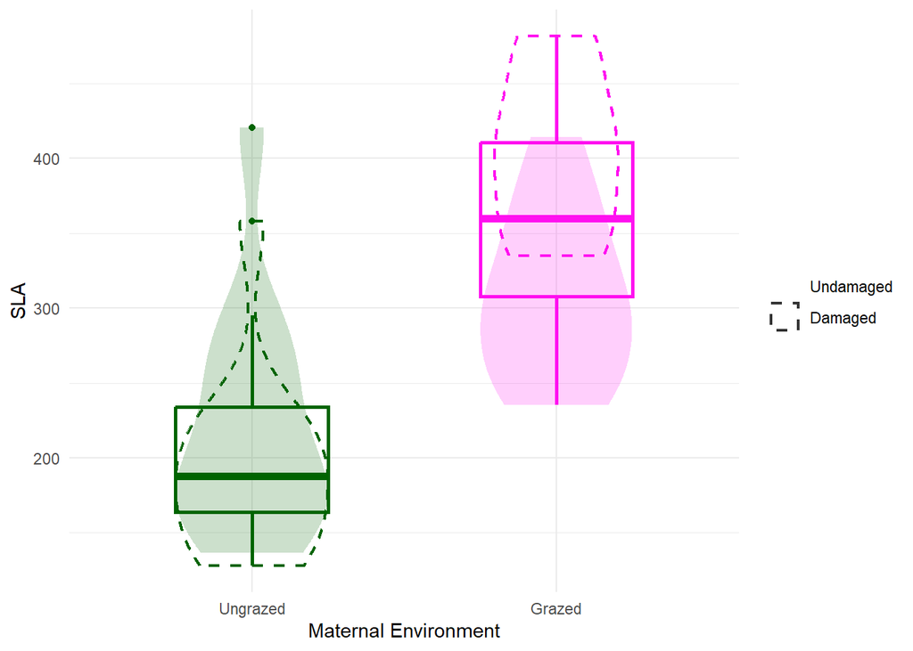

### A.barbata - LDMC

**sqrt(LDMC) ~ trat + clip + trat:clip**  
n = **41**

R² = **0.5328737**

##### AVLDMC Post-hoc Comparisons with Tukeys HSD

| contrast | trat | estimate | SE | df | t.ratio | p.value |
| --- | --- | --- | --- | --- | --- | --- |
| no - yes | ex | -0.0278450 | 0.0175313 | 37 | -1.588307 | 0.1207269 |
| no - yes | gra | 0.0265852 | 0.0197984 | 37 | 1.342798 | 0.1875177 |

| contrast | clip | estimate | SE | df | t.ratio | p.value |
| --- | --- | --- | --- | --- | --- | --- |
| ex - gra | no | 0.0613633 | 0.0185197 | 37 | 3.313408 | 0.0020684 |
| ex - gra | yes | 0.1157936 | 0.0188770 | 37 | 6.134101 | 0.0000004 |

ANOVA Results for AVLDMC Model

| Response | Predictor | Sum Sq | Df | F value | Pr(>F) |
| --- | --- | --- | --- | --- | --- |
| AV LDMC | trat *** | 0.078 | 1 | 44.369 | 0.000 |
| AV LDMC | clip | 0.000 | 1 | 0.089 | 0.767 |
| AV LDMC | trat:clip * | 0.007 | 1 | 4.236 | 0.047 |
| AV LDMC | Residuals | 0.065 | 37 | NA | NA |

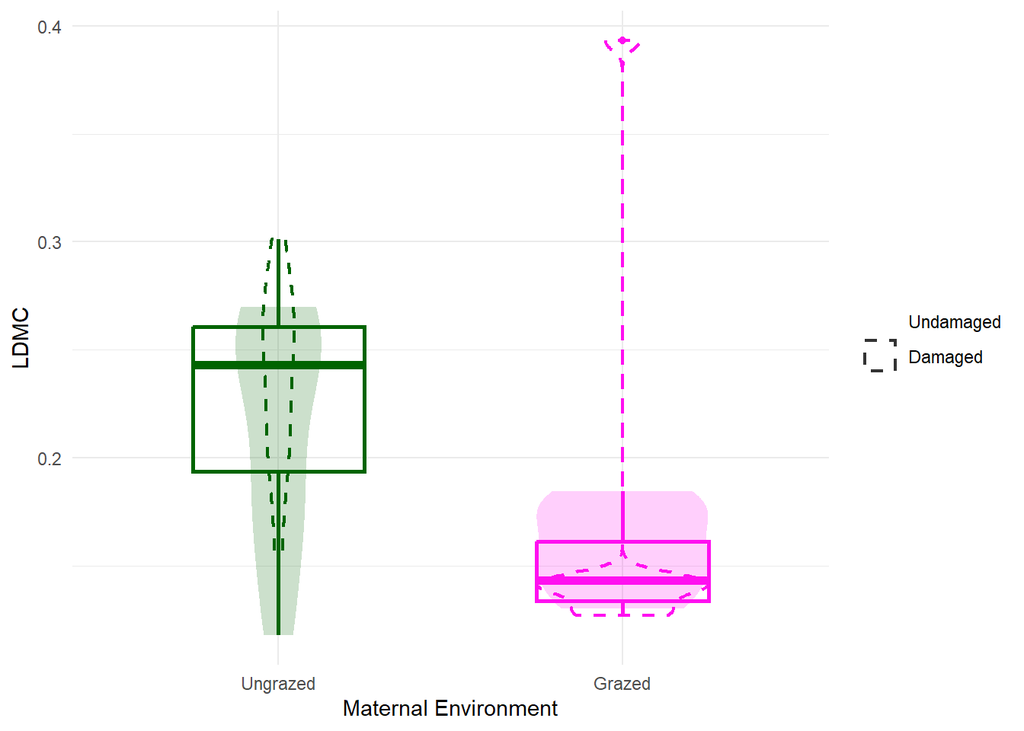

### A.barbata - ÁREA FOLIAR

**sqrt(area.m) ~ trat + clip + trat:clip**  
n = **45**

R² = **0.403981**

##### AVarea.m Post-hoc Comparisons with Tukeys HSD

| contrast | trat | estimate | SE | df | t.ratio | p.value |
| --- | --- | --- | --- | --- | --- | --- |
| no - yes | ex | -0.0976012 | 0.2276380 | 41 | -0.428756 | 0.6703452 |
| no - yes | gra | 0.4234694 | 0.2543033 | 41 | 1.665214 | 0.1034946 |

| contrast | clip | estimate | SE | df | t.ratio | p.value |
| --- | --- | --- | --- | --- | --- | --- |
| ex - gra | no | 0.6737038 | 0.2391825 | 41 | 2.816694 | 0.0074293 |
| ex - gra | yes | 1.1947744 | 0.2434769 | 41 | 4.907136 | 0.0000151 |

ANOVA Results for AVarea.m Model

| Response | Predictor | Sum Sq | Df | F value | Pr(>F) |
| --- | --- | --- | --- | --- | --- |
| AV area.m | trat *** | 9.598 | 1 | 29.683 | 0.000 |
| AV area.m | clip | 0.202 | 1 | 0.626 | 0.433 |
| AV area.m | trat:clip | 0.754 | 1 | 2.331 | 0.135 |
| AV area.m | Residuals | 13.257 | 41 | NA | NA |

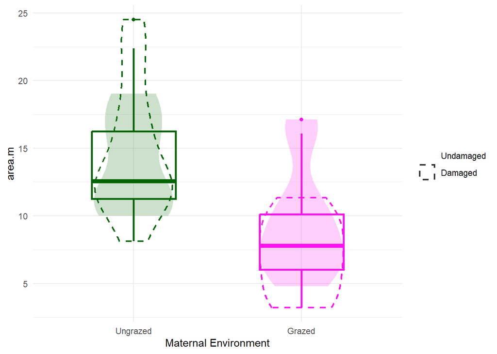

### A.barbata - TASA FOTOSINTÉTICA

**sqrt(Photosyn) ~ trat + clip + trat:clip**  
n = **30**

[output not shown]

[output not shown]

[output not shown]

[output not shown]

[output not shown]

[output not shown]

[output not shown]

[output not shown]

[output not shown]

[output not shown]

[output not shown]

[output not shown]

[output not shown]

R² = **-0.0087694**

##### AVPhotosyn Post-hoc Comparisons with Tukeys HSD

| contrast | trat | estimate | SE | df | t.ratio | p.value |
| --- | --- | --- | --- | --- | --- | --- |
| no - yes | ex | -0.1692990 | 0.3568444 | 26 | -0.4744336 | 0.6391513 |
| no - yes | gra | 0.3867471 | 0.3854360 | 26 | 1.0034015 | 0.3249148 |

| contrast | clip | estimate | SE | df | t.ratio | p.value |
| --- | --- | --- | --- | --- | --- | --- |
| ex - gra | no | -0.5719823 | 0.3568444 | 26 | -1.602890 | 0.1210398 |
| ex - gra | yes | -0.0159363 | 0.3854360 | 26 | -0.041346 | 0.9673359 |

ANOVA Results for AVPhotosyn Model

| Response | Predictor | Sum Sq | Df | F value | Pr(>F) |
| --- | --- | --- | --- | --- | --- |
| AV Photosyn | trat | 0.739 | 1 | 1.450 | 0.239 |
| AV Photosyn | clip | 0.057 | 1 | 0.111 | 0.741 |
| AV Photosyn | trat:clip | 0.571 | 1 | 1.121 | 0.300 |
| AV Photosyn | Residuals | 13.243 | 26 | NA | NA |

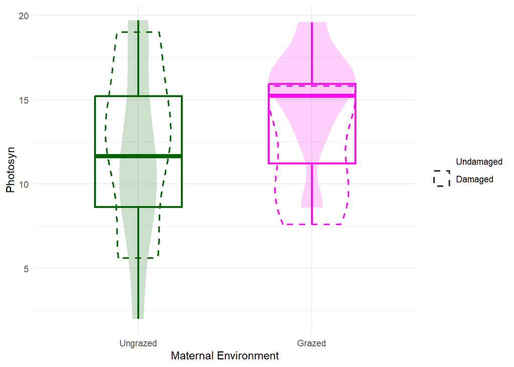

### A.barbata - CONDUCTANCIA ESTOMÁTICA

**sqrt(Conductance) ~ trat + clip + trat:clip**  
n = **30**

[output not shown]

[output not shown]

[output not shown]

[output not shown]

[output not shown]

[output not shown]

R² = **0.0786166**

##### AVConductance Post-hoc Comparisons with Tukeys HSD

| contrast | trat | estimate | SE | df | t.ratio | p.value |
| --- | --- | --- | --- | --- | --- | --- |
| no - yes | ex | -0.0776101 | 0.0446133 | 26 | -1.739618 | 0.0937534 |
| no - yes | gra | 0.0734693 | 0.0481878 | 26 | 1.524644 | 0.1394208 |

| contrast | clip | estimate | SE | df | t.ratio | p.value |
| --- | --- | --- | --- | --- | --- | --- |
| ex - gra | no | -0.0817718 | 0.0446133 | 26 | -1.832904 | 0.0782927 |
| ex - gra | yes | 0.0693075 | 0.0481878 | 26 | 1.438278 | 0.1622843 |

ANOVA Results for AVConductance Model

| Response | Predictor | Sum Sq | Df | F value | Pr(>F) |
| --- | --- | --- | --- | --- | --- |
| AV Conductance | trat | 0.001 | 1 | 0.135 | 0.716 |
| AV Conductance | clip | 0.000 | 1 | 0.058 | 0.812 |
| AV Conductance | trat:clip * | 0.042 | 1 | 5.293 | 0.030 |
| AV Conductance | Residuals | 0.207 | 26 | NA | NA |

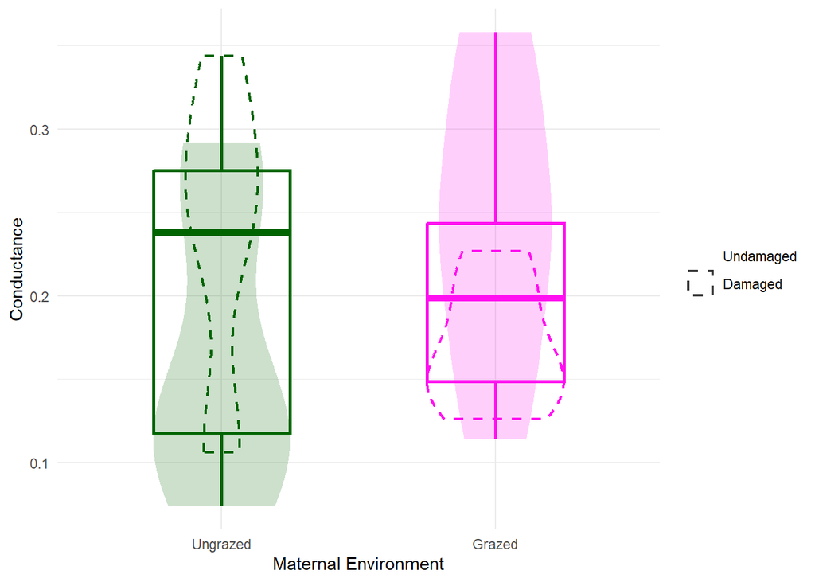

### A.barbata - EFICIENCIA DEL FOTOSISTEMA II

**sqrt(PhiPS2) ~ trat + clip + trat:clip**  
n = **30**

R² = **0.1932264**

##### AVPhiPS2 Post-hoc Comparisons with Tukeys HSD

| contrast | trat | estimate | SE | df | t.ratio | p.value |
| --- | --- | --- | --- | --- | --- | --- |
| no - yes | ex | -0.0153214 | 0.0235102 | 26 | -0.6516936 | 0.5203185 |
| no - yes | gra | -0.0149268 | 0.0253939 | 26 | -0.5878088 | 0.5617318 |

| contrast | clip | estimate | SE | df | t.ratio | p.value |
| --- | --- | --- | --- | --- | --- | --- |
| ex - gra | no | -0.0533873 | 0.0235102 | 26 | -2.270816 | 0.0316758 |
| ex - gra | yes | -0.0529926 | 0.0253939 | 26 | -2.086825 | 0.0468527 |

ANOVA Results for AVPhiPS2 Model

| Response | Predictor | Sum Sq | Df | F value | Pr(>F) |
| --- | --- | --- | --- | --- | --- |
| AV PhiPS2 | trat ** | 0.021 | 1 | 9.511 | 0.005 |
| AV PhiPS2 | clip | 0.002 | 1 | 0.770 | 0.388 |
| AV PhiPS2 | trat:clip | 0.000 | 1 | 0.000 | 0.991 |
| AV PhiPS2 | Residuals | 0.057 | 26 | NA | NA |

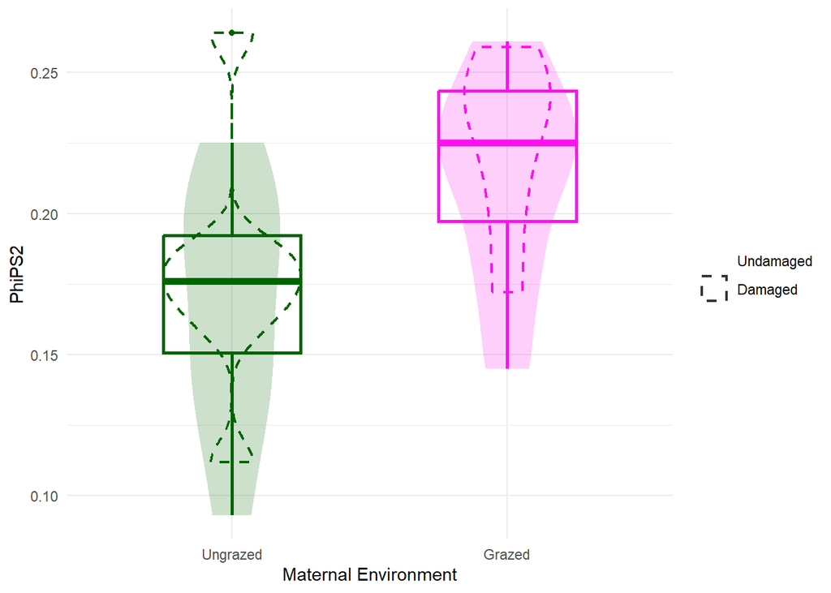

### A.barbata - FENOLOGÍA DE FLORACIÓN

**sqrt(dias_flor) ~ trat + clip + trat:clip**  
n = **50**

R² = **-0.0089248**

##### AVdias_flor Post-hoc Comparisons with Tukeys HSD

| contrast | trat | estimate | SE | df | t.ratio | p.value |
| --- | --- | --- | --- | --- | --- | --- |
| no - yes | ex | -0.3288219 | 0.2748700 | 46 | -1.1962815 | 0.2377165 |
| no - yes | gra | 0.0880482 | 0.2978915 | 46 | 0.2955713 | 0.7688876 |

| contrast | clip | estimate | SE | df | t.ratio | p.value |
| --- | --- | --- | --- | --- | --- | --- |
| ex - gra | no | -0.0091276 | 0.2923605 | 46 | -0.0312204 | 0.9752289 |
| ex - gra | yes | 0.4077424 | 0.2807457 | 46 | 1.4523549 | 0.1531903 |

ANOVA Results for AVdias_flor Model

| Response | Predictor | Sum Sq | Df | F value | Pr(>F) |
| --- | --- | --- | --- | --- | --- |
| AV dias_flor | trat | 0.536 | 1 | 1.053 | 0.310 |
| AV dias_flor | clip | 0.235 | 1 | 0.461 | 0.501 |
| AV dias_flor | trat:clip | 0.539 | 1 | 1.058 | 0.309 |
| AV dias_flor | Residuals | 23.427 | 46 | NA | NA |

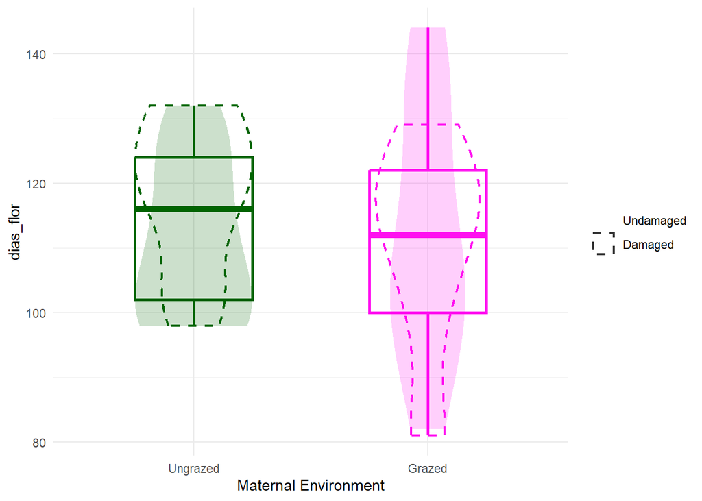

### A.barbata - FENOLOGÍA DE FRUCTIFICACÓN

**sqrt(dias_fruto) ~ trat + clip + trat:clip**  
n = **35**

R² = **-0.0612002**

##### AVdias_fruto Post-hoc Comparisons with Tukeys HSD

| contrast | trat | estimate | SE | df | t.ratio | p.value |
| --- | --- | --- | --- | --- | --- | --- |
| no - yes | ex | -0.0959878 | 0.2608636 | 31 | -0.3679617 | 0.7154024 |
| no - yes | gra | -0.2299939 | 0.2438104 | 31 | -0.9433307 | 0.3528061 |

| contrast | clip | estimate | SE | df | t.ratio | p.value |
| --- | --- | --- | --- | --- | --- | --- |
| ex - gra | no | 0.114410 | 0.2388342 | 31 | 0.4790355 | 0.6352753 |
| ex - gra | yes | -0.019596 | 0.2654272 | 31 | -0.0738281 | 0.9416215 |

ANOVA Results for AVdias_fruto Model

| Response | Predictor | Sum Sq | Df | F value | Pr(>F) |
| --- | --- | --- | --- | --- | --- |
| AV dias_fruto | trat | 0.025 | 1 | 0.094 | 0.761 |
| AV dias_fruto | clip | 0.234 | 1 | 0.884 | 0.354 |
| AV dias_fruto | trat:clip | 0.037 | 1 | 0.141 | 0.710 |
| AV dias_fruto | Residuals | 8.190 | 31 | NA | NA |

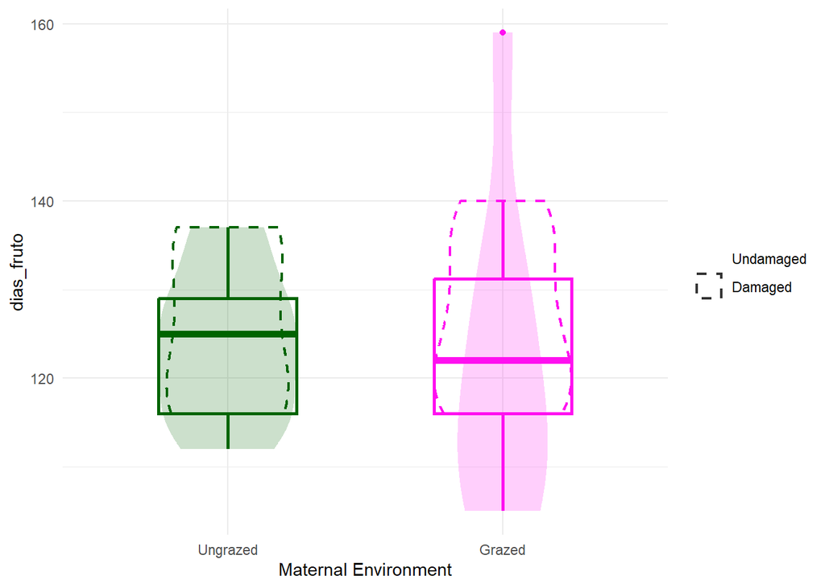

### A.barbata - PERIODO DE FLORACIÓN

**sqrt(periodo_flor) ~ trat + clip + trat:clip**  
n = **14**

R² = **0.5071338**

##### AVperiodo_flor Post-hoc Comparisons with Tukeys HSD

| contrast | trat | estimate | SE | df | t.ratio | p.value |
| --- | --- | --- | --- | --- | --- | --- |
| no - yes | ex | -0.2397725 | 0.5663096 | 10 | -0.4233947 | 0.6809692 |
| no - yes | gra | -3.0996200 | 0.7706498 | 10 | -4.0220864 | 0.0024303 |

| contrast | clip | estimate | SE | df | t.ratio | p.value |
| --- | --- | --- | --- | --- | --- | --- |
| ex - gra | no | 1.686807 | 0.7063122 | 10 | 2.388189 | 0.0380762 |
| ex - gra | yes | -1.173040 | 0.6447719 | 10 | -1.819311 | 0.0988881 |

ANOVA Results for AVperiodo_flor Model

| Response | Predictor | Sum Sq | Df | F value | Pr(>F) |
| --- | --- | --- | --- | --- | --- |
| AV periodo_flor | trat | 0.051 | 1 | 0.071 | 0.795 |
| AV periodo_flor | clip * | 5.284 | 1 | 7.414 | 0.021 |
| AV periodo_flor | trat:clip * | 6.373 | 1 | 8.942 | 0.014 |
| AV periodo_flor | Residuals | 7.127 | 10 | NA | NA |

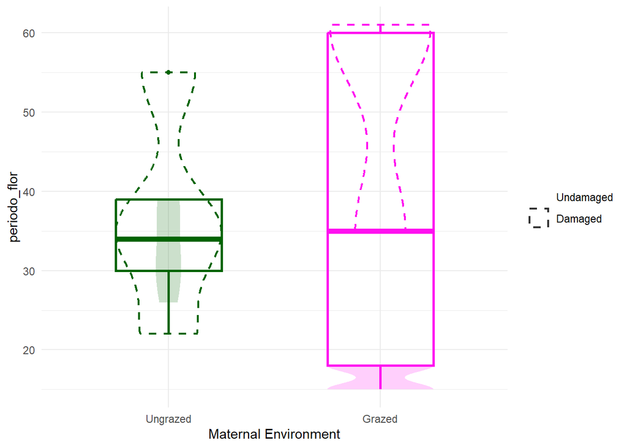

### A.barbata - PERIODO DE FRUCTIFICACIÓN

**sqrt(periodo_fruto) ~ trat + clip + trat:clip**

n = **13**

R² = **0.65345**

##### AVperiodo_fruto Post-hoc Comparisons with Tukeys HSD

| contrast | trat | estimate | SE | df | t.ratio | p.value |
| --- | --- | --- | --- | --- | --- | --- |
| no - yes | ex | -0.3425394 | 0.8403485 | 9 | -0.4076159 | 0.6930811 |
| no - yes | gra | -4.3034809 | 0.8983704 | 9 | -4.7903194 | 0.0009870 |

| contrast | clip | estimate | SE | df | t.ratio | p.value |
| --- | --- | --- | --- | --- | --- | --- |
| ex - gra | no | 1.034412 | 0.8403485 | 9 | 1.230933 | 0.2495457 |
| ex - gra | yes | -2.926529 | 0.8983704 | 9 | -3.257598 | 0.0098766 |

ANOVA Results for AVperiodo_fruto Model

| Response | Predictor | Sum Sq | Df | F value | Pr(>F) |
| --- | --- | --- | --- | --- | --- |
| AV periodo_fruto | trat | 2.130 | 1 | 1.759 | 0.217 |
| AV periodo_fruto | clip ** | 15.430 | 1 | 12.746 | 0.006 |
| AV periodo_fruto | trat:clip * | 12.551 | 1 | 10.368 | 0.010 |
| AV periodo_fruto | Residuals | 10.895 | 9 | NA | NA |

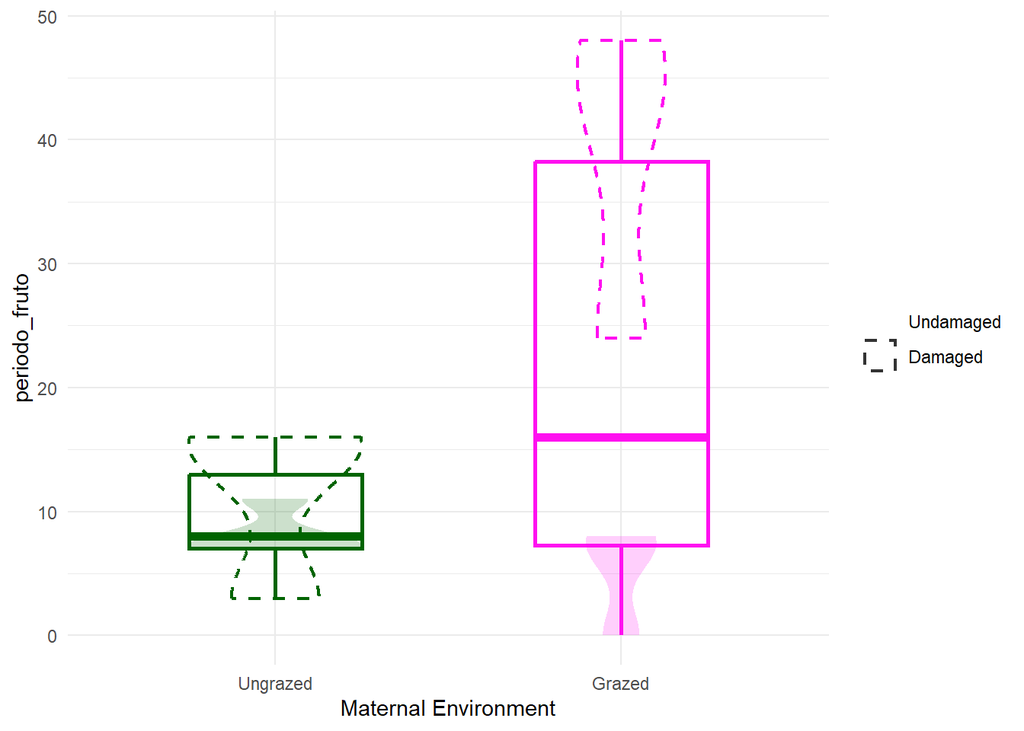

### A.barbata - ESPERANZA DE VIDA

**sqrt(dias_muerte) ~ trat + clip + trat:clip**  
n = **10**

R² = **0.0294299**

##### AVdias_muerte Post-hoc Comparisons with Tukeys HSD

| contrast | trat | estimate | SE | df | t.ratio | p.value |
| --- | --- | --- | --- | --- | --- | --- |
| no - yes | ex | 0.7757783 | 0.6261011 | 6 | 1.239062 | 0.2615918 |
| no - yes | gra | -0.8009926 | 0.6261011 | 6 | -1.279334 | 0.2480236 |

| contrast | clip | estimate | SE | df | t.ratio | p.value |
| --- | --- | --- | --- | --- | --- | --- |
| ex - gra | no | 1.0838701 | 0.6858594 | 6 | 1.580309 | 0.1651180 |
| ex - gra | yes | -0.4929008 | 0.5600019 | 6 | -0.880177 | 0.4126257 |

ANOVA Results for AVdias_muerte Model

| Response | Predictor | Sum Sq | Df | F value | Pr(>F) |
| --- | --- | --- | --- | --- | --- |
| AV dias_muerte | trat | 0.047 | 1 | 0.101 | 0.761 |
| AV dias_muerte | clip | 0.000 | 1 | 0.001 | 0.978 |
| AV dias_muerte | trat:clip | 1.492 | 1 | 3.171 | 0.125 |
| AV dias_muerte | Residuals | 2.822 | 6 | NA | NA |

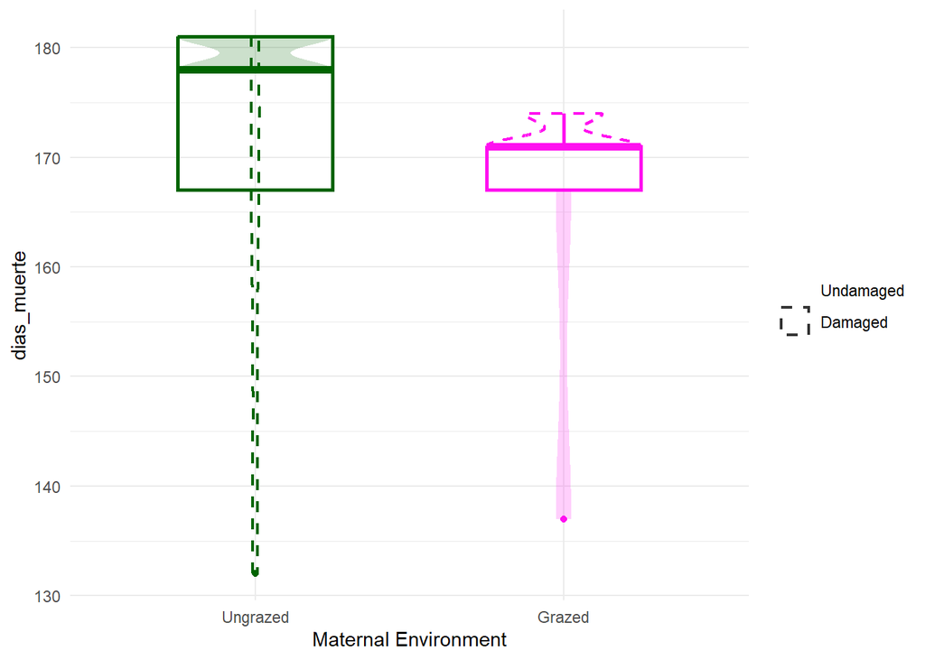

### A.barbata - FENOLES

**sqrt(fenoles) ~ trat + clip + trat:clip**  
n = **49**

R² = **0.2166304**

##### AVfenoles Post-hoc Comparisons with Tukeys HSD

| contrast | trat | estimate | SE | df | t.ratio | p.value |
| --- | --- | --- | --- | --- | --- | --- |
| no - yes | ex | 0.0136868 | 0.2358611 | 45 | 0.0580291 | 0.9539824 |
| no - yes | gra | 0.3027243 | 0.2398194 | 45 | 1.2623012 | 0.2133433 |

| contrast | clip | estimate | SE | df | t.ratio | p.value |
| --- | --- | --- | --- | --- | --- | --- |
| ex - gra | no | -0.7988494 | 0.2358611 | 45 | -3.386949 | 0.0014767 |
| ex - gra | yes | -0.5098120 | 0.2398194 | 45 | -2.125817 | 0.0390402 |

ANOVA Results for AVfenoles Model

| Response | Predictor | Sum Sq | Df | F value | Pr(>F) |
| --- | --- | --- | --- | --- | --- |
| AV fenoles | trat *** | 5.227 | 1 | 15.252 | 0.000 |
| AV fenoles | clip | 0.294 | 1 | 0.858 | 0.359 |
| AV fenoles | trat:clip | 0.253 | 1 | 0.738 | 0.395 |
| AV fenoles | Residuals | 15.421 | 45 | NA | NA |

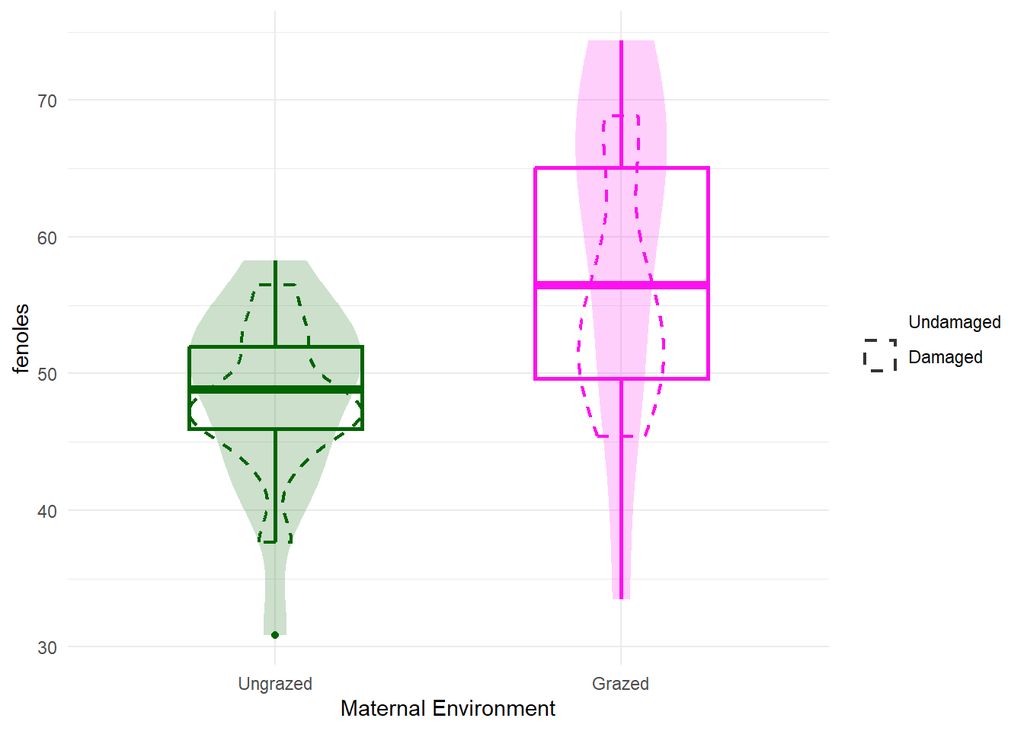